# Tugas Pertemuan 2 MPDW

Kaylila Kireinahana

2023-09-05

```r
library(dplyr)
library(TTR)
library(forecast)
library(lmtest) #digunakan untuk uji formal pendeteksian autokorelasi
library(orcutt) #untuk membuat model regresi Cochrane-Orcutt
library(HoRM) #untuk membuat model regresi Hildreth-Lu
library(rio)
# Import Data
new.delhi<-import("https://raw.githubusercontent.com/reiflection/MPDW/main/Data/New%20Delhi%20Air%20Quality.csv")
```

```r
#Membentuk objek time series
aqi.ts<-ts(new.delhi$AQI)
aqi.ts
```

```
## Time Series:
## Start = 1
## End = 72
## Frequency = 1
##  [1] 30.2 28.2 26.6 25.0 26.0 26.0 26.0 24.0 23.0 24.0 25.0 26.0 27.0 29.0 29.0
## [16] 29.0 29.0 28.0 27.0 27.0 27.0 27.0 27.0 27.0 27.0 28.0 29.0 31.0 31.0 32.0
## [31] 32.0 31.0 31.0 30.0 30.0 29.0 27.0 26.0 25.0 25.0 24.0 24.0 25.0 25.0 25.0
## [46] 26.0 26.0 27.0 27.0 27.0 27.0 28.0 28.0 27.0 27.0 26.0 25.0 23.0 22.0 21.0
## [61] 20.0 19.0 19.0 20.0 21.0 21.0 21.0 22.0 24.0 26.0 27.0 28.0
```

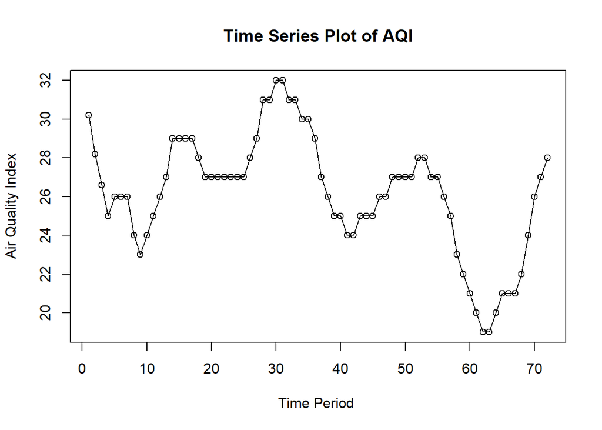

```r
#Membuat plot time series
ts.plot(aqi.ts, xlab="Time Period ", ylab="Air Quality Index", main= "Time Series Plot of AQI")

points(aqi.ts)
```

Dari plot time series diatas, dapat disimpulkan bahwa pola yang terlihat adalah pola *tren*.

## Double Moving Average

```r
aqi.sma <- SMA(aqi.ts, n=4)
nddma <- SMA(aqi.sma, n=4)
at_aqi <- 2*aqi.sma - nddma
bt_aqi <- 2/(4-1)*(aqi.sma - nddma)
aqi.dma<- at_aqi+bt_aqi
aqi.ramal<- c(NA, aqi.sma)

t = 1:5
f = c()

for (i in t) {
  f[i] = at_aqi[length(at_aqi)] + bt_aqi[length(bt_aqi)]*(i)
}
```

```r
aqi.gab <- cbind(aktual = c(aqi.ts,rep(NA,5)),
                pemulusan1 = c(aqi.sma,rep(NA,5)),
                pemulusan2 = c(aqi.dma, rep(NA,5)),
                At = c(at_aqi, rep(NA,5)),
                Bt = c(bt_aqi,rep(NA,5)),
                ramalan = c(aqi.ramal, f[-1]))
aqi.gab
```

```
##       aktual pemulusan1 pemulusan2      At          Bt  ramalan
##  [1,]   30.2         NA         NA      NA          NA       NA
##  [2,]   28.2         NA         NA      NA          NA       NA
##  [3,]   26.6         NA         NA      NA          NA       NA
##  [4,]   25.0      27.50         NA      NA          NA       NA
##  [5,]   26.0      26.45         NA      NA          NA 27.50000
##  [6,]   26.0      25.90         NA      NA          NA 26.45000
##  [7,]   26.0      25.75   24.66667 25.1000 -0.43333333 25.90000
##  [8,]   24.0      25.50   24.83333 25.1000 -0.26666667 25.75000
##  [9,]   23.0      24.75   23.54167 24.0250 -0.48333333 25.50000
## [10,]   24.0      24.25   22.89583 23.4375 -0.54166667 24.75000
## [11,]   25.0      24.00   22.95833 23.3750 -0.41666667 24.25000
## [12,]   26.0      24.50   24.70833 24.6250  0.08333333 24.00000
## [13,]   27.0      25.50   27.06250 26.4375  0.62500000 24.50000
## [14,]   29.0      26.75   29.35417 28.3125  1.04166667 25.50000
```

[output cut: 63 more lines]

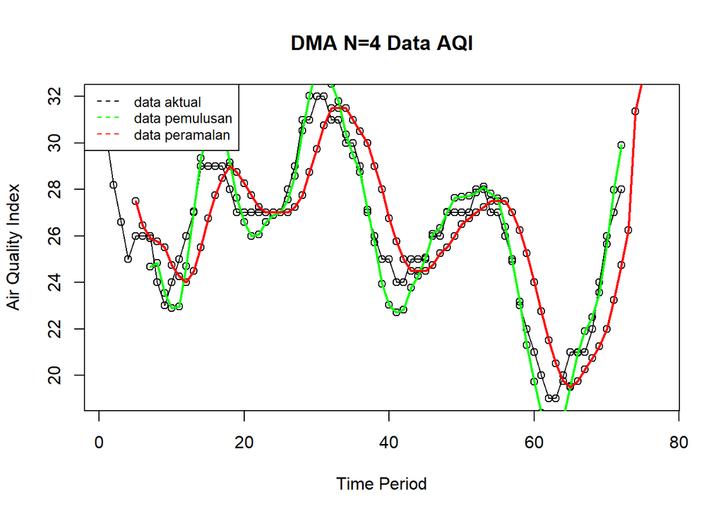

```r
#Plot time series
ts.plot(aqi.gab[,1], xlab="Time Period", ylab="Air Quality Index",
        main= "DMA N=4 Data AQI")
points(aqi.gab[,1])
points(aqi.gab[,3])
points(aqi.gab[,6])
lines(aqi.gab[,3],col="green",lwd=2)
lines(aqi.gab[,6],col="red",lwd=2)
legend("topleft",c("data aktual","data pemulusan","data peramalan"),
       lty=8, col=c("black","green","red"), cex=0.8)
```

Selanjutnya akan dilihat keakuratan dari DMA.

```r
#Menghitung nilai keakuratan
aqi_dma.error = aqi.ts-aqi.ramal[1:length(aqi.ts)]
aqi_dma.sse = sum(aqi_dma.error[5:length(aqi.ts)]^2)
aqi_dma.mse= mean(aqi_dma.error[5:length(aqi.ts)]^2)
aqi_dma.mape = mean(abs((aqi_dma.error[5:length(aqi.ts)]/aqi.ts[5:length(aqi.ts)])*100))

aqi_dma.akurasi <- matrix(c(aqi_dma.sse, aqi_dma.mse, aqi_dma.mape))
row.names(aqi_dma.akurasi)<- c("SSE", "MSE", "MAPE")
colnames(aqi_dma.akurasi) <- c("Akurasi m = 4")
aqi_dma.akurasi
```

```
##      Akurasi m = 4
## SSE      230.08750
## MSE        3.38364
## MAPE       5.95407
```

Nilai keakurasian MAPE dibawah 10%. Hal ini menunjukkan bahwa DMA menunjukkan keakurasian yang baik.

## Double Exponential Smoothing

Selanjutnya akan digunakan metode *Double Exponential Smoothing* dengan cara sebagai berikut.

Pertama akan data akan dibagi menjadi data *training* dan data *testing*.

```r
#membagi training dan testing
aqi_train <- new.delhi$AQI[1:58]
aqi_test <- new.delhi$AQI[58:72]

#data time series
aqi_train.ts<-ts(aqi_train)
aqi_test.ts<-ts(aqi_test)

#eksplorasi data
par(nfrow=c(1,3))
```

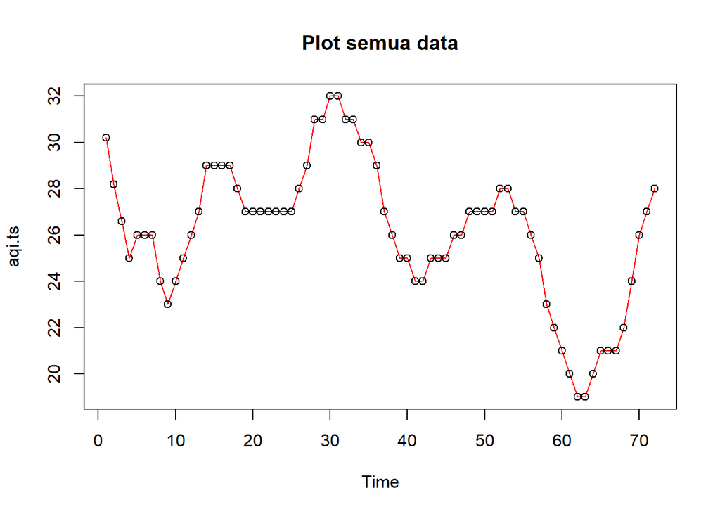

```r
plot(aqi.ts, col="red",main="Plot semua data")
points(aqi.ts)
```

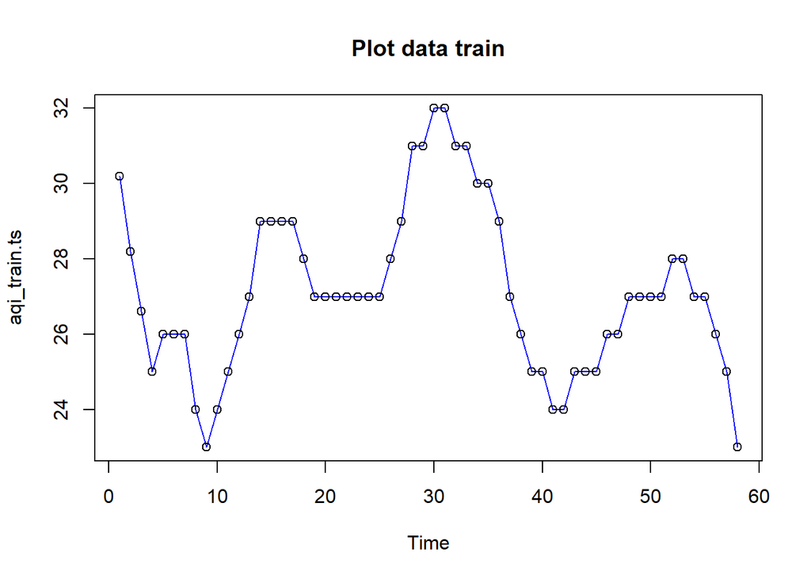

```r
plot(aqi_train.ts, col="blue",main="Plot data train")
points(aqi_train.ts)
```

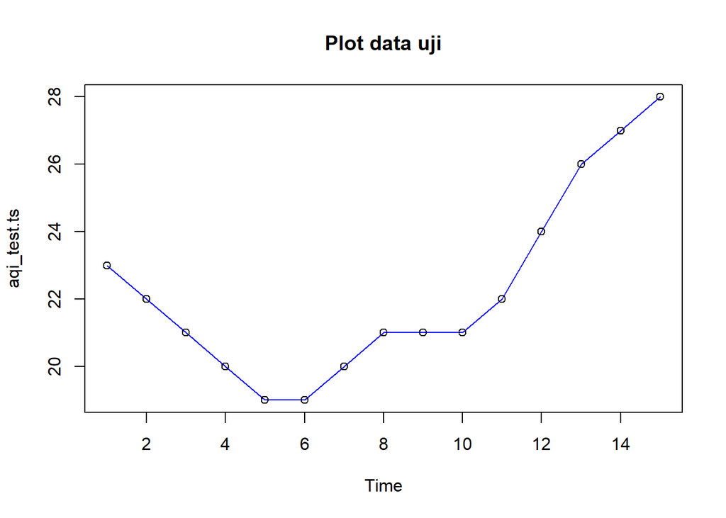

```r
plot(aqi_test.ts, col="blue",main="Plot data uji")
points(aqi_test.ts)
```

```r
#Lamda dan gamma optimum
aqi_des.opt<- HoltWinters(aqi_train.ts, gamma = FALSE)
aqi_des.opt
```

```
## Holt-Winters exponential smoothing with trend and without seasonal component.
##
## Call:
## HoltWinters(x = aqi_train.ts, gamma = FALSE)
##
## Smoothing parameters:
##  alpha: 1
##  beta : 0.5554289
##  gamma: FALSE
##
## Coefficients:
##        [,1]
## a 23.000000
## b -1.484768
```

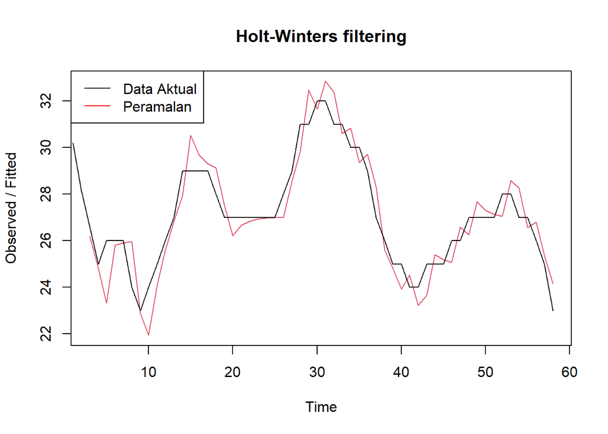

```r
plot(aqi_des.opt)
legend("topleft", c("Data Aktual", "Peramalan"), col = c("black", "red"),
       lty = c(1,1))
```

```r
#ramalan
aqi.ramalandesopt<- forecast(aqi_des.opt, h=15)
aqi.ramalandesopt
```

```
##    Point Forecast       Lo 80    Hi 80      Lo 95    Hi 95
## 59     21.5152319  20.3494285 22.68104  19.732289 23.29817
## 60     20.0304638  17.8747173 22.18621  16.733534 23.32739
## 61     18.5456957  15.2741514 21.81724  13.542300 23.54909
## 62     17.0609276  12.5481742 21.57368  10.159267 23.96259
## 63     15.5761595   9.7049048 21.44741   6.596850 24.55547
## 64     14.0913914   6.7523428 21.43044   2.867285 25.31550
## 65     12.6066233   3.6974416 21.51580  -1.018794 26.23204
## 66     11.1218552   0.5461354 21.69758  -5.052313 27.29602
## 67      9.6370871  -2.6964929 21.97067  -9.225496 28.49967
## 68      8.1523190  -6.0260492 22.33069 -13.531624 29.83626
## 69      6.6675509  -9.4386963 22.77380 -17.964829 31.29993
## 70      5.1827828 -12.9310514 23.29662 -22.519936 32.88550
## 71      3.6980147 -16.5001056 23.89613 -27.192345 34.58837
## 72      2.2132466 -20.1431615 24.56965 -31.977929 36.40442
## 73      0.7284785 -23.8577843 25.31474 -36.872966 38.32992
```

```r
aqi_train_dse.sse <- aqi_des.opt$SSE
aqi_train_dse.mse <- aqi_train_dse.sse/length(aqi_train.ts)
aqi_train_des.sisaan <- aqi.ramalandesopt$residuals
head(aqi_train_des.sisaan)
```

```
## Time Series:
## Start = 1
## End = 6
## Frequency = 1
## [1]        NA        NA 0.4000000 0.1778284 2.6790574 0.1910314
```

```r
aqi_train_dse.mape <- sum(abs(aqi_train_des.sisaan[3:length(aqi_train.ts)]/aqi_train.ts[3:length(aqi_train.ts)])*100)/length(aqi_train.ts)

aqi_des.opt.akurasi <- matrix(c(aqi_train_dse.sse,aqi_train_dse.mse,aqi_train_dse.mape))
row.names(aqi_des.opt.akurasi)<- c("SSE", "MSE", "MAPE")
colnames(aqi_des.opt.akurasi) <- c("Akurasi lamda dan gamma optimum")
aqi_des.opt.akurasi
```

```
##      Akurasi lamda dan gamma optimum
## SSE                       45.5289640
## MSE                        0.7849821
## MAPE                       2.5720741
```

## Perbandingan DMA dan DES

```r
cbind(aqi_dma.akurasi, aqi_des.opt.akurasi)
```

```
##      Akurasi m = 4 Akurasi lamda dan gamma optimum
## SSE      230.08750                      45.5289640
## MSE        3.38364                       0.7849821
## MAPE       5.95407                       2.5720741
```

Berdasarkan perbandingan akurasi tersebut, terlihat nilai SSE, MSE, dan MAPE metode DES lebih kecil dibandingkan dengan metode DMA. Oleh karena itu, metode peramalan dan pemulusan yang terbaik antara keduanya adalah dengan metode DES.

Setelah melakukan peramalan, data yang telah dimasukkan kemudian dieksplorasi. Eksplorasi pertama yang dilakukan adalah dengan menggunakan *scatter plot*.

## Eksplorasi Data

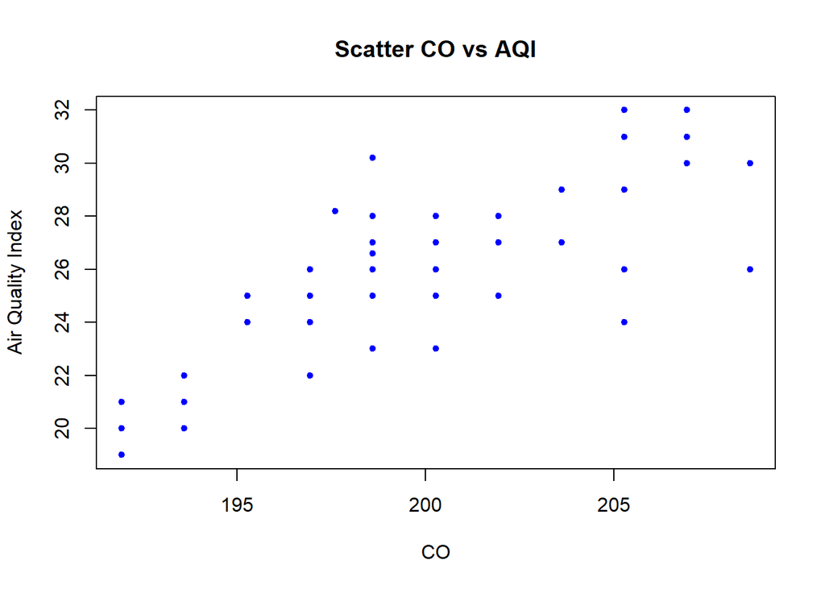

```r
#Pembuatan Scatter Plot
plot(new.delhi$CO, new.delhi$AQI, pch = 20, col = "blue",
     main = "Scatter CO vs AQI",
     xlab = "CO",
     ylab = "Air Quality Index")
```

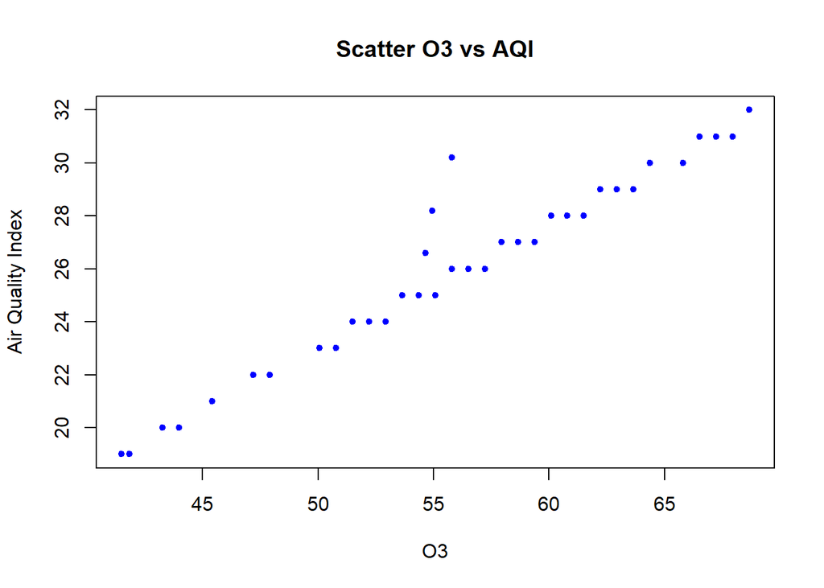

```r
plot(new.delhi$o3, new.delhi$AQI, pch = 20, col = "blue",
     main = "Scatter O3 vs AQI",
     xlab = "O3",
     ylab = "Air Quality Index")
```

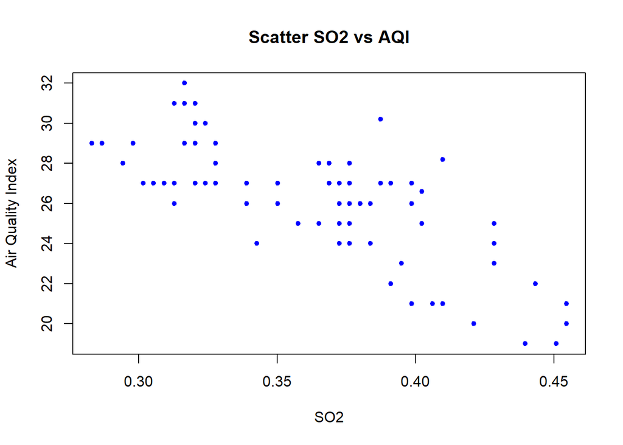

```r
plot(new.delhi$so2, new.delhi$AQI, pch = 20, col = "blue",
     main = "Scatter SO2 vs AQI",
     xlab = "SO2",
     ylab = "Air Quality Index")
```

```r
#Menampilkan Nilai Korelasi
cor(new.delhi$CO, new.delhi$AQI)
```

```
## [1] 0.7976332
```

```r
cor(new.delhi$o3, new.delhi$AQI)
```

```
## [1] 0.973599
```

```r
cor(new.delhi$so2, new.delhi$AQI)
```

```
## [1] -0.7424781
```

Setalah mengetahui adanya hubungan antar dua peubah, maka model regresi dapat ditentukan.

```r
aqi.model<- lm(AQI ~ CO + o3 + so2, data = new.delhi)
summary(aqi.model)
```

```
##
## Call:
## lm(formula = AQI ~ CO + o3 + so2, data = new.delhi)
##
## Residuals:
##     Min      1Q  Median      3Q     Max
## -0.6297 -0.3961 -0.0265  0.1540  4.3012
##
## Coefficients:
##              Estimate Std. Error t value Pr(>|t|)
## (Intercept) -2.130858   7.389425  -0.288    0.774
## CO          -0.002784   0.036556  -0.076    0.940
## o3           0.485279   0.024961  19.442   <2e-16 ***
## so2          3.894798   3.338980   1.166    0.248
## ---
## Signif. codes:  0 '***' 0.001 '**' 0.01 '*' 0.05 '.' 0.1 ' ' 1
##
## Residual standard error: 0.7034 on 68 degrees of freedom
## Multiple R-squared:  0.9492, Adjusted R-squared:  0.947
## F-statistic: 423.6 on 3 and 68 DF,  p-value: < 2.2e-16
```

Selanjutnya dilakukan uji terhadap sisaannya seperti berikut ini.

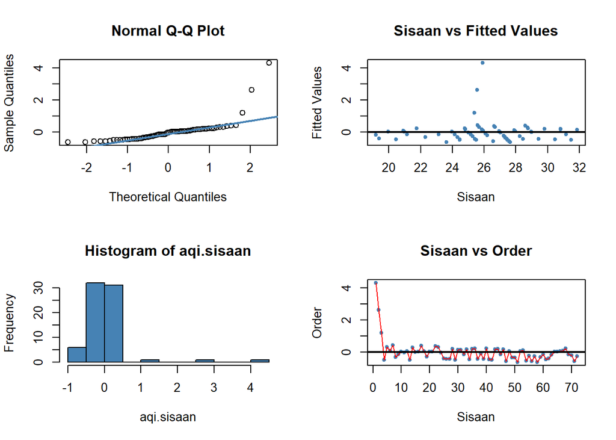

```r
#sisaan dan fitted value
aqi.sisaan<- residuals(aqi.model)
aqi.fitValue<- predict(aqi.model)

#Diagnostik dengan eksploratif
par(mfrow = c(2,2))
qqnorm(aqi.sisaan)
qqline(aqi.sisaan, col = "steelblue", lwd = 2)
plot(aqi.fitValue, aqi.sisaan, col = "steelblue", pch = 20, xlab = "Sisaan", ylab = "Fitted Values", main = "Sisaan vs Fitted Values")
abline(a = 0, b = 0, lwd = 2)
hist(aqi.sisaan, col = "steelblue")
plot(seq(1,72,1), aqi.sisaan, col = "steelblue", pch = 20, xlab = "Sisaan", ylab = "Order", main = "Sisaan vs Order")
lines(seq(1,72,1), aqi.sisaan, col = "red")
abline(a = 0, b = 0, lwd = 2)
```

Dua plot di samping kiri digunakan untuk melihat apakah sisaan menyebar normal. Normal Q-Q Plot di atas menunjukkan bahwa sisaan cenderung menyebar normal, tetapi histogram dari sisaan tidak menunjukkan demikian. Selanjutnya, dua plot di samping kanan digunakan untuk melihat autokorelasi. Plot Sisaan vs *Fitted Value* dan Plot Sisaan vs *Order* menunjukkan adanya pola pada sisaan. Untuk lebih lanjut akan digunakan uji formal melihat normalitas sisaan dan plot ACF dan PACF untuk melihat apakah ada autokorelasi atau tidak.

## Uji Asumsi

```r
#Melihat Sisaan Menyebar Normal/Tidak
#H0: sisaan mengikuti sebaran normal
#H1: sisaan tidak mengikuti sebaran normal
shapiro.test(aqi.sisaan)
```

```
##
##  Shapiro-Wilk normality test
##
## data:  aqi.sisaan
## W = 0.57832, p-value = 4.579e-13
```

```r
ks.test(aqi.sisaan, "pnorm", mean=mean(aqi.sisaan), sd=sd(aqi.sisaan))
```

```
##
##  Asymptotic one-sample Kolmogorov-Smirnov test
##
## data:  aqi.sisaan
## D = 0.23982, p-value = 0.000506
## alternative hypothesis: two-sided
```

Berdasarkan uji formal Saphiro-Wilk dan Kolmogorov-Smirnov didapatkan nilai *p-value* < $\alpha$ (5%). Artinya, belum cukup bukti untuk menyatakan sisaan berdistribusi normal.

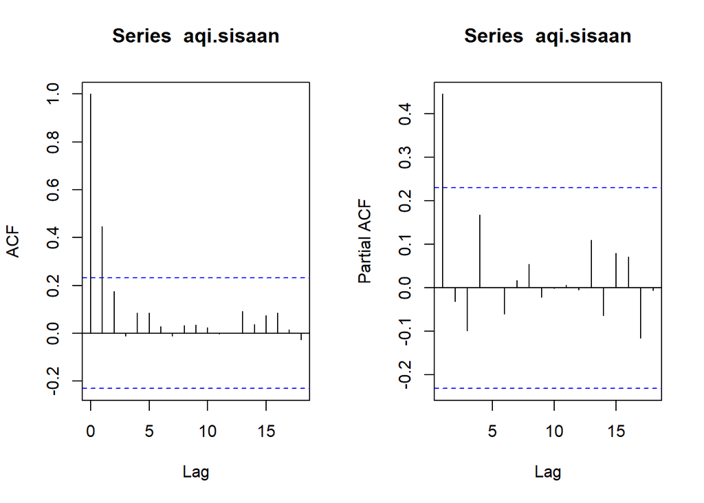

```r
#ACF dan PACF identifikasi autokorelasi
par(mfrow = c(1,2))
acf(aqi.sisaan)
pacf(aqi.sisaan)
```

```r
#Deteksi autokorelasi dengan uji-Durbin Watson
#H0: tidak ada autokorelasi
#H1: ada autokorelasi
library(lmtest)
dwtest(aqi.model)
```

```
##
##  Durbin-Watson test
##
## data:  aqi.model
## DW = 0.55676, p-value = 1.13e-14
## alternative hypothesis: true autocorrelation is greater than 0
```

Berdasarkan hasil DW Test, didapatkan nilai $DW = 0.55676$ dan *p-value* = $1.13e-14$. Berdasarkan tabel Durbin-Watson diperoleh nilai $DL = 0.1.5029$ dan $DU = 1.7366$. Nilai DW berada di bawah nilai DL dan DU. Artinya, terdapat autokorelasi positif. Namun, dengan nilai *p-value* \< 0.05 dapat disimpulkan bahwa tolak H0, cukup bukti mengatakan adanya autokorelasi. Oleh karena itu, diperlukan penangan autokorelasi. Penanganan yang akan digunakan menggunakan dua metode, yaitu Cochrane-Orcutt dan Hildret-Lu.

Melalui test Durbin-Watson, *p-value* < $\alpha$ (5%) yang menandakan bahwa terdapat autokorelasi.

## Penanganan Autokorelasi

### Metode Cochrane-Orcutt

```r
library (orcutt)
#Penanganan Autokorelasi Cochrane-Orcutt
aqi.modelCO<-cochrane.orcutt(aqi.model)
aqi.modelCO
```

```
## Cochrane-orcutt estimation for first order autocorrelation
##
## Call:
## lm(formula = AQI ~ CO + o3 + so2, data = new.delhi)
##
##  number of interaction: 9
##  rho 0.46121
##
## Durbin-Watson statistic
## (original):    0.55676 , p-value: 1.13e-14
## (transformed): 2.71731 , p-value: 9.976e-01
##
##  coefficients:
## (Intercept)          CO          o3         so2
##    4.989103   -0.031450    0.483940   -0.027116
```

Model regresi berubah menjadi
$$y_i=4.989103-0.031450x_1+0.483940x_2-0.027116x_3$$

Nilai p-value setelah menggunakan metode Cochrane-Orcutt menjadi lebih besar yaitu 0.9976 yang menandakan bahwa model tidak lagi mengalami autokorelasi.

```r
#Rho optimum
aqi.rho<- aqi.modelCO$rho
aqi.rho
```

```
## [1] 0.4612096
```

```r
#Transformasi Manual
aqi.trans<- new.delhi$AQI[-1] - new.delhi$AQI[-72]*aqi.rho
CO.trans<- new.delhi$CO[-1] - new.delhi$CO[-72]*aqi.rho
o3.trans<- new.delhi$o3[-1] - new.delhi$o3[-72]*aqi.rho
so2.trans <- new.delhi$so2[-1] - new.delhi$so2[-72]*aqi.rho

aqi.modelCOmanual<- lm(aqi.trans ~ CO.trans + o3.trans + so2.trans)
summary(aqi.modelCOmanual)
```

```
##
## Call:
## lm(formula = aqi.trans ~ CO.trans + o3.trans + so2.trans)
##
## Residuals:
##      Min       1Q   Median       3Q      Max
## -0.93684 -0.23232  0.04205  0.18381  0.79208
##
## Coefficients:
##             Estimate Std. Error t value Pr(>|t|)
## (Intercept)  2.68808    3.13685   0.857    0.395
## CO.trans    -0.03145    0.02819  -1.115    0.269
## o3.trans     0.48394    0.01940  24.943   <2e-16 ***
## so2.trans   -0.02712    2.69876  -0.010    0.992
## ---
## Signif. codes:  0 '***' 0.001 '**' 0.01 '*' 0.05 '.' 0.1 ' ' 1
##
## Residual standard error: 0.3435 on 67 degrees of freedom
## Multiple R-squared:  0.9635, Adjusted R-squared:  0.9619
## F-statistic: 589.6 on 3 and 67 DF,  p-value: < 2.2e-16
```

```r
#Mencari Penduga Koefisien Regresi setelah Transformasi ke Persamaan Awal
aqi.b0bintang <- aqi.modelCOmanual$coefficients[c(-2,-3)]
aqi.b0 <- aqi.b0bintang/(1-aqi.rho)
aqi.b1 <- aqi.modelCOmanual$coefficients[c(-1,-3)]
aqi.b2 <- aqi.modelCOmanual$coefficients[c(-1,-2)]
aqi.b0
```

```
## (Intercept)   so2.trans
##   4.9891032  -0.0503278
```

```r
aqi.b1
```

```
##    CO.trans   so2.trans
## -0.03145040 -0.02711614
```

```r
aqi.b2
```

```
##    o3.trans   so2.trans
##  0.48394031 -0.02711614
```

```r
aqi.modelCO
```

```
## Cochrane-orcutt estimation for first order autocorrelation
##
## Call:
## lm(formula = AQI ~ CO + o3 + so2, data = new.delhi)
##
##  number of interaction: 9
##  rho 0.46121
##
## Durbin-Watson statistic
## (original):    0.55676 , p-value: 1.13e-14
## (transformed): 2.71731 , p-value: 9.976e-01
##
##  coefficients:
## (Intercept)          CO          o3         so2
##    4.989103   -0.031450    0.483940   -0.027116
```

Koefisien hasil transformasi manual dan fungsi sudah sesuai.

### Metode Hildreth-Lu

```r
#Penanganan Autokorelasi Hildreth lu
# Hildreth-Lu
hildreth.lu.func<- function(r, model){
  x1 <- model.matrix(model)[,c(-1,-3,-4)]
  x2 <- model.matrix(model)[,c(-1,-2,-4)]
  x3 <- model.matrix(model)[,c(-1,-2,-3)]
  y <- model.response(model.frame(model))
  n <- length(y)
  t <- 2:n
  y <- y[t]-r*y[t-1]
  x1 <- x1[t]-r*x1[t-1]
  x2 <- x2[t]-r*x2[t-1]
  x3 <- x3[t]-r*x3[t-1]

  return(lm(y ~ x1 + x2 + x3))
}

#Pencariab rho yang meminimumkan SSE
aqi.r <- c(seq(0,1, by= 0.1))
aqi.tab <- data.frame("rho" = aqi.r, "SSE" = sapply(aqi.r, function(i){deviance(hildreth.lu.func(i, aqi.model))}))
round(aqi.tab, 4)
```

```
##    rho     SSE
## 1  0.0 14.7412
## 2  0.1 12.0739
## 3  0.2 10.0700
## 4  0.3  8.7231
## 5  0.4  8.0226
## 6  0.5  7.9523
## 7  0.6  8.4915
## 8  0.7  9.6241
## 9  0.8 11.3621
## 10 0.9 13.7733
## 11 1.0 16.9576
```

Dari tabel SSE diatas, terlihat bahwa nilai SSE terkecil terdapat pada rentang nilai rho $0.4$ hingga $0.6$.

```r
#Rho optimal di sekitar 0.9
aqi.rOpt <- seq(0.4,0.6, by= 0.0001)
aqi.tabOpt <- data.frame("rho" = aqi.rOpt, "SSE" = sapply(aqi.rOpt, function(i){deviance(hildreth.lu.func(i, aqi.model))}))
head(aqi.tabOpt[order(aqi.tabOpt$SSE),])
```

```
##        rho      SSE
## 613 0.4612 7.905985
## 614 0.4613 7.905985
## 612 0.4611 7.905985
## 615 0.4614 7.905986
## 611 0.4610 7.905986
## 616 0.4615 7.905987
```

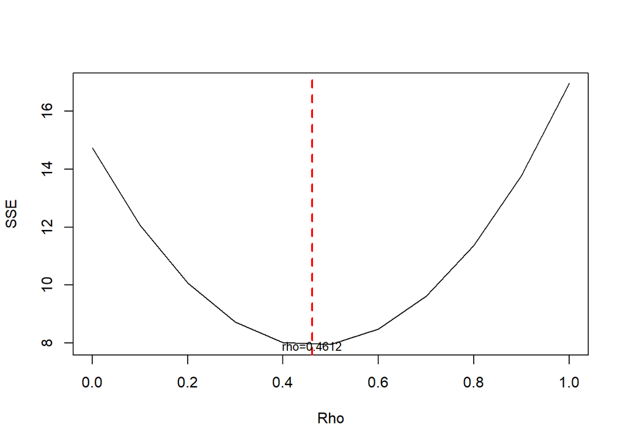

```r
#Grafik SSE optimum
par(mfrow = c(1,1))
plot(aqi.tab$SSE ~ aqi.tab$rho , type = "l", xlab = "Rho", ylab = "SSE")
abline(v = aqi.tabOpt[aqi.tabOpt$SSE==min(aqi.tabOpt$SSE),"rho"], lty = 2, col="red",lwd=2)
text(x=0.4612, y=7.905985, labels = "rho=0.4612", cex = 0.8)
```

Nilai rho terkecil jatuh pada $0.4612$ dengan nilai SSE $7.905985$.

```r
#Model terbaik
aqi.modelHL <- hildreth.lu.func(0.4612, aqi.model)
summary(aqi.modelHL)
```

```
##
## Call:
## lm(formula = y ~ x1 + x2 + x3)
##
## Residuals:
##      Min       1Q   Median       3Q      Max
## -0.93683 -0.23232  0.04205  0.18381  0.79212
##
## Coefficients:
##             Estimate Std. Error t value Pr(>|t|)
## (Intercept)  2.68797    3.13687   0.857    0.395
## x1          -0.03145    0.02819  -1.115    0.269
## x2           0.48394    0.01940  24.943   <2e-16 ***
## x3          -0.02702    2.69873  -0.010    0.992
## ---
## Signif. codes:  0 '***' 0.001 '**' 0.01 '*' 0.05 '.' 0.1 ' ' 1
##
## Residual standard error: 0.3435 on 67 degrees of freedom
## Multiple R-squared:  0.9635, Adjusted R-squared:  0.9619
## F-statistic: 589.6 on 3 and 67 DF,  p-value: < 2.2e-16
```

```r
#Transformasi Balik
cat("y = ", coef(aqi.modelHL)[1]/(1-0.4612), coef(aqi.modelHL)[2], "x1","+", coef(aqi.modelHL)[3], "x2", coef(aqi.modelHL)[4], "x3", sep = "")
```

```
## y = 4.988816-0.03144901x1+0.4839399x2-0.02702217x3
```

```r
#Deteksi autokorelasi
dwtest(aqi.modelHL)
```

```
##
##  Durbin-Watson test
##
## data:  aqi.modelHL
## DW = 2.7173, p-value = 0.9976
## alternative hypothesis: true autocorrelation is greater than 0
```

Koefisien model dan hasil Durbin-Watson test dari metode Hildreth-Lu dengan metode Cochrane-Orcutt mengeluarkan hasil yang sama.

```r
#Perbandingan
aqi.sseModelawal <- anova(aqi.model)$`Sum Sq`[c(-1, -2, -3)]
aqi.sseModelCO <- anova(aqi.modelCOmanual)$`Sum Sq`[c(-1, -2, -3)]
aqi.sseModelHL <- anova(aqi.modelHL)$`Sum Sq`[c(-1,-2, -3)]
aqi.mseModelawal <- aqi.sseModelawal/length(new.delhi$AQI)
aqi.mseModelCO <- aqi.sseModelCO/length(new.delhi$AQI)
aqi.mseModelHL <- aqi.sseModelHL/length(new.delhi$AQI)
aqi.akurasi <- matrix(c(aqi.sseModelawal, aqi.sseModelCO, aqi.sseModelHL,
                        aqi.mseModelawal, aqi.mseModelCO, aqi.mseModelHL),nrow = 2, ncol = 3,byrow = T)
colnames(aqi.akurasi) <- c("Model Awal", "Model Cochrane-Orcutt", "Model Hildreth-Lu")
row.names(aqi.akurasi) <- c("SSE","MSE")
aqi.akurasi
```

```
##     Model Awal Model Cochrane-Orcutt Model Hildreth-Lu
## SSE 33.6474846             7.9059848         7.9059848
## MSE  0.4673262             0.1098053         0.1098053
```

Berdasarkan hasil tersebut dapat diketahui bahwa hasil penanganan autokorelasi dengan metode Cochrane-Orcutt dan Hildreth-Lu memiliki SSE yang hampir sama, sebesar $7.9059848$ dan lebih baik dibandingkan model awal ketika autokorelasi masih terjadi, yaitu sebesar $33.6474846$.